# DietTable and DNW

BH & JP

2017-06-07

Load packages

```r
library(httr)
library(plyr)
library(ggplot2)
library(mgcv)
library(reshape2)
library(gtools)
```

## Things to do

Read in fish DietTable form globi and fish ecology table from globi-fishbase Cobine files and select relevant columns (i.e diet, habitat (marine/freshwater), trophic level)

NOTE - no consumers prey on chondricthyes or clittelata - these can be removed but not rightn now as that will mess up the code…

```r
ecology <- read.csv('ecology_fishbase.csv')
diet <- read.csv('fbDietMatrix20170607.tsv', sep='\t')
dietEcology <- merge(x = diet, y = ecology, by = 'SpecCode')

diet.sum<-dietEcology[,c(1:33, 63,68,73,74,79,80)]
```

## Convert diet to presence/absence

Replace diet values with 1/0

```r
diet.sum[,c(5:33)][diet.sum[,c(5:33)] > 0] <- 1
```

## Generate number of GBIF occurences

The next step is to determine the number of occurence of each species in GBIF.

## Test for relationship between DNW and GBIFocc

Script to retrieve GBIF occ by GBIF id - this takes 10-15 mins to run so avoid where possible to save time I have saved the GBIF counts in a seperate DF, delete these lines from the final script…

```r
diet.sum$gbif.taxon.occ.count <- lapply(diet.sum$gbif.taxon.id, function(taxonKey) {
    resp <- httr::GET(paste('http://api.gbif.org/v1/occurrence/count?taxonKey=',taxonKey, sep=""))
    message('.', appendLF=FALSE)
    httr::stop_for_status(resp)
    httr::content(resp)
})
```

[output not shown]

```r
diet.sum$gbif.taxon.occ.count <- unlist(diet.sum$gbif.taxon.occ.count)
diet.sum<-subset(diet.sum, gbif.taxon.occ.count > 0)
diet.sum$OCClog <- log(diet.sum$gbif.taxon.occ.count)
GBIF<-diet.sum[,c(1:3,40)]
```

Split diet table into marine and freshwater fishes

## Marine

```r
marine<-subset(diet.sum, Marine == -1 & Freshwater == 0)
marine$DNW<-rowSums(marine[,c(5:8,10:26,28:33)])/27 #remove clitelata and chondrythes now...
marine<-subset(marine, DNW > 0)
```

Plot relationship between DNW and GBIF occurences, GBIF occurences are log transformed to normalise the range

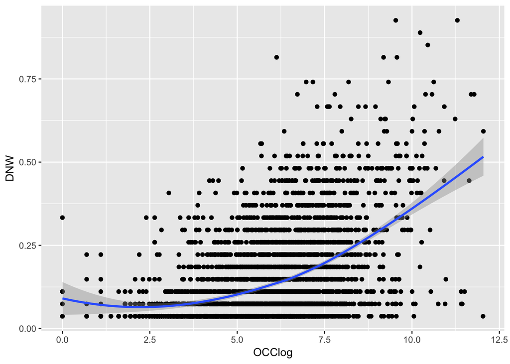

```r
ggplot(marine, aes(OCClog, DNW)) +
  geom_point() +
  geom_smooth(method = "loess")
```

Positive relationship between DNW and OCClog Run a gam to ‘correct’ for this relationship. DNWcorr is the residuals of this model and will be used for subsequent analysis

```r
gam.marine<-gam(DNW ~ s(OCClog), data=marine)
summary(gam.marine)
```

```
##
## Family: gaussian
## Link function: identity
##
## Formula:
## DNW ~ s(OCClog)
##
## Parametric coefficients:
##             Estimate Std. Error t value Pr(>|t|)
## (Intercept) 0.143733   0.001998   71.95   <2e-16 ***
## ---
## Signif. codes:  0 '***' 0.001 '**' 0.01 '*' 0.05 '.' 0.1 ' ' 1
##
## Approximate significance of smooth terms:
##             edf Ref.df     F p-value
## s(OCClog) 8.631  8.954 127.1  <2e-16 ***
## ---
## Signif. codes:  0 '***' 0.001 '**' 0.01 '*' 0.05 '.' 0.1 ' ' 1
##
## R-sq.(adj) =  0.242   Deviance explained = 24.4%
## GCV = 0.014196  Scale est. = 0.014157  n = 3548
```

```r
marine$DNWcorr<-residuals(gam.marine)
marine$biome<-"Marine"
```

## Freshwater

subset to only get species observed in Freshwater

Several prey groups (namely; cnidaria.other, Anthozoa, Clitellata, Polyplacophora, Cephalopoda, Brachiopoda, Echinodermata, Ophiuroidea, Holothuroidea) are exclusively marine groups and were not recorded in the diet of freshwater fish. These groups were removed from DNW calculation.

NOTE - Cnidaria.other, Cephalopoda & Echinodermata were prey categories for a small number (n<10) freshwater fishes. In some cases this is anadromous species (eg Onchyrinchus sp.) but others (eg cyprinids: Tinca tinca, Rutilus rutilus) seem strange. These may require some futher checking of GLOBI sources….

Next step is to caculate DNW for freshwater fishes, n prey types / total prey types (18)

```r
fresh<-subset(diet.sum, Marine == 0 & Freshwater == -1)
summary(fresh)
```

```
##     SpecCode                    predator.name  gbif.taxon.id
##  Min.   :   74   Salmo trutta          :   3   Min.   :2332724
##  1st Qu.: 4949   Oncorhynchus clarkii  :   2   1st Qu.:2355627
##  Median :10395   Oreochromis spilurus  :   2   Median :2370523
##  Mean   :18656   Polypterus palmas     :   2   Mean   :2998847
##  3rd Qu.:26829   Sarotherodon galilaeus:   2   3rd Qu.:2402266
##  Max.   :67790   Abramites hypselonotus:   1   Max.   :8616148
##                  (Other)               :1729
##  dietary.niche.width Cnidaria.other        Anthozoa Annelida.other
##  Min.   : 0.00       Min.   :0.000000   Min.   :0   Min.   :0.00000
##  1st Qu.: 1.00       1st Qu.:0.000000   1st Qu.:0   1st Qu.:0.00000
##  Median : 2.00       Median :0.000000   Median :0   Median :0.00000
##  Mean   : 2.38       Mean   :0.003446   Mean   :0   Mean   :0.01666
##  3rd Qu.: 3.00       3rd Qu.:0.000000   3rd Qu.:0   3rd Qu.:0.00000
##  Max.   :17.00       Max.   :1.000000   Max.   :0   Max.   :1.00000
##
##    Polychaeta         Clitellata Mollusca.other   Polyplacophora
##  Min.   :0.000000   Min.   :0    Min.   :0.0000   Min.   :0
##  1st Qu.:0.000000   1st Qu.:0    1st Qu.:0.0000   1st Qu.:0
##  Median :0.000000   Median :0    Median :0.0000   Median :0
##  Mean   :0.008041   Mean   :0    Mean   :0.1626   Mean   :0
##  3rd Qu.:0.000000   3rd Qu.:0    3rd Qu.:0.0000   3rd Qu.:0
##  Max.   :1.000000   Max.   :0    Max.   :1.0000   Max.   :0
##
##     Bivalvia         Gastropoda       Cephalopoda       Brachiopoda.other
##  Min.   :0.00000   Min.   :0.00000   Min.   :0.000000   Min.   :0
##  1st Qu.:0.00000   1st Qu.:0.00000   1st Qu.:0.000000   1st Qu.:0
##  Median :0.00000   Median :0.00000   Median :0.000000   Median :0
##  Mean   :0.02183   Mean   :0.04538   Mean   :0.002298   Mean   :0
##  3rd Qu.:0.00000   3rd Qu.:0.00000   3rd Qu.:0.000000   3rd Qu.:0
##  Max.   :1.00000   Max.   :1.00000   Max.   :1.000000   Max.   :0
##
##  Arthropoda.other    Ostracoda        Maxillopoda       Malacostraca
##  Min.   :0.00000   Min.   :0.00000   Min.   :0.00000   Min.   :0.00000
##  1st Qu.:0.00000   1st Qu.:0.00000   1st Qu.:0.00000   1st Qu.:0.00000
##  Median :0.00000   Median :0.00000   Median :0.00000   Median :0.00000
##  Mean   :0.08329   Mean   :0.04365   Mean   :0.03733   Mean   :0.08156
##  3rd Qu.:0.00000   3rd Qu.:0.00000   3rd Qu.:0.00000   3rd Qu.:0.00000
##  Max.   :1.00000   Max.   :1.00000   Max.   :1.00000   Max.   :1.00000
##
```

[output cut: 33 more lines]

```
##  null   :1569   2      : 177   0      : 181   Min.   :     1
##  0      :  31   3.2    : 138   0.4    : 172   1st Qu.:    25
##  0.1    :   8   null   : 127   null   : 127   Median :    89
##  0.53   :   7   3.5    :  93   0.37   :  93   Mean   :  1685
##  0.35   :   6   3.4    :  55   0.45   :  93   3rd Qu.:   320
##  0.14   :   5   4.2    :  31   0.5    :  49   Max.   :289530
##  (Other): 115   (Other):1120   (Other):1026
##      OCClog
##  Min.   : 0.000
##  1st Qu.: 3.219
##  Median : 4.489
##  Mean   : 4.596
##  3rd Qu.: 5.768
##  Max.   :12.576
##
```

```r
fresh<-fresh[,-c(5,6,9,11,14,15,21:24,27)]
fresh$DNW<-rowSums(fresh[,c(5:22)])/18
fresh<-subset(fresh, DNW > 0)
```

Plot relationship between DNW and GBIF occurences, GBIF occurences are log transformed to normalise the range

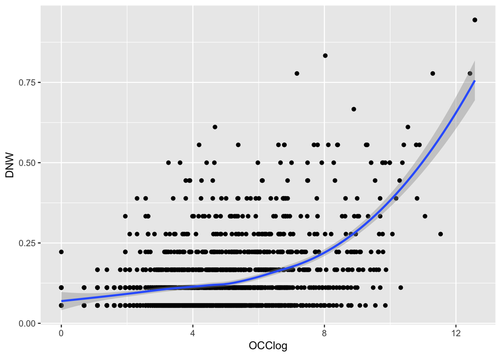

```r
ggplot(fresh, aes(OCClog, DNW)) +
  geom_point() +
  geom_smooth(method = "loess")
```

Positive relationship between DNW and OCClog Run a gam to ‘correct’ for this relationship. DNWcorr is the residuals of this model and will be used for subsequent analysis

```r
gam.fresh<-gam(DNW ~ s(OCClog), data=fresh)
summary(gam.fresh)
```

```
##
## Family: gaussian
## Link function: identity
##
## Formula:
## DNW ~ s(OCClog)
##
## Parametric coefficients:
##             Estimate Std. Error t value Pr(>|t|)
## (Intercept) 0.132309   0.002217   59.67   <2e-16 ***
## ---
## Signif. codes:  0 '***' 0.001 '**' 0.01 '*' 0.05 '.' 0.1 ' ' 1
##
## Approximate significance of smooth terms:
##             edf Ref.df     F p-value
## s(OCClog) 7.388  8.299 88.29  <2e-16 ***
## ---
## Signif. codes:  0 '***' 0.001 '**' 0.01 '*' 0.05 '.' 0.1 ' ' 1
##
## R-sq.(adj) =  0.297   Deviance explained =   30%
## GCV = 0.0085714  Scale est. = 0.00853   n = 1735
```

```r
fresh$DNWcorr<-residuals(gam.fresh)
fresh$biome<-"Fresh"
```

Combine marine and freshwater datasets Quick plot to check everything and compare between biomes

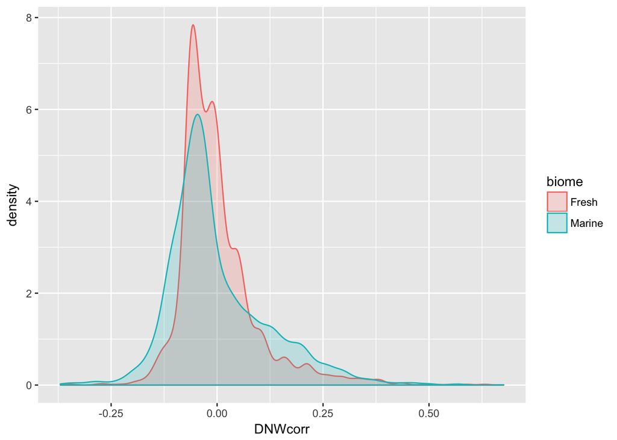

```r
DietTable<-smartbind(marine, fresh)

ggplot(DietTable, aes(DNWcorr, fill=biome, colour=biome)) +
  geom_density(alpha=0.2)
```

Now for some fun comparisons….

is there any relationship between niche width and trophic level? First need to change TL values from factor to numberic

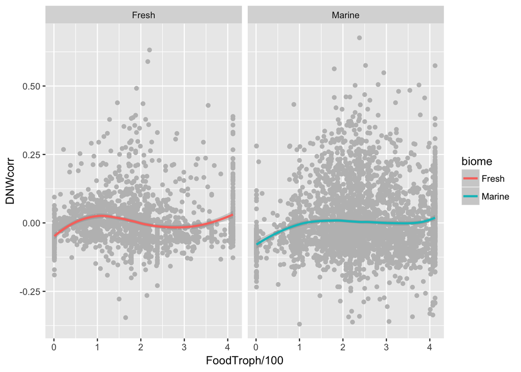

```r
DietTable$DietTroph<-as.numeric(DietTable$DietTroph)
DietTable$FoodTroph<-as.numeric(DietTable$FoodTroph)
ggplot(DietTable, aes(y = DNWcorr, x = FoodTroph/100, colour=biome)) +
  geom_point(colour = "grey") +
  geom_smooth(method = "loess") +
  facet_grid(. ~ biome)
```

PCA to search for trends in diet

```r
mar.PC<-marine[,c(5:8,10:26,28:33)]
summary(DietTable)
```

```
##     SpecCode                    predator.name  gbif.taxon.id
##  Min.   :    5   Salmo trutta          :   3   Min.   :2332595
##  1st Qu.: 3052   Oncorhynchus clarkii  :   2   1st Qu.:2371992
##  Median : 6583   Oreochromis spilurus  :   2   Median :2392427
##  Mean   :12820   Polypterus palmas     :   2   Mean   :2977077
##  3rd Qu.:13188   Sarotherodon galilaeus:   2   3rd Qu.:2416946
##  Max.   :67790   Sprattus sprattus     :   2   Max.   :8652393
##                  (Other)               :5270
##  dietary.niche.width Cnidaria.other      Anthozoa      Annelida.other
##  Min.   : 1.000      Min.   :0.0000   Min.   :0.0000   Min.   :0.00000
##  1st Qu.: 1.000      1st Qu.:0.0000   1st Qu.:0.0000   1st Qu.:0.00000
##  Median : 2.000      Median :0.0000   Median :0.0000   Median :0.00000
##  Mean   : 3.391      Mean   :0.1187   Mean   :0.0389   Mean   :0.03634
##  3rd Qu.: 4.000      3rd Qu.:0.0000   3rd Qu.:0.0000   3rd Qu.:0.00000
##  Max.   :25.000      Max.   :1.0000   Max.   :1.0000   Max.   :1.00000
##                      NA's   :1735     NA's   :1735
##    Polychaeta       Clitellata   Mollusca.other   Polyplacophora
##  Min.   :0.0000   Min.   :0      Min.   :0.0000   Min.   :0.0000
##  1st Qu.:0.0000   1st Qu.:0      1st Qu.:0.0000   1st Qu.:0.0000
##  Median :0.0000   Median :0      Median :0.0000   Median :0.0000
##  Mean   :0.1469   Mean   :0      Mean   :0.2947   Mean   :0.0166
##  3rd Qu.:0.0000   3rd Qu.:0      3rd Qu.:1.0000   3rd Qu.:0.0000
##  Max.   :1.0000   Max.   :0      Max.   :1.0000   Max.   :1.0000
##                   NA's   :1735                    NA's   :1735
##     Bivalvia         Gastropoda      Cephalopoda    Brachiopoda.other
##  Min.   :0.00000   Min.   :0.0000   Min.   :0.000   Min.   :0.0000
##  1st Qu.:0.00000   1st Qu.:0.0000   1st Qu.:0.000   1st Qu.:0.0000
##  Median :0.00000   Median :0.0000   Median :0.000   Median :0.0000
##  Mean   :0.08707   Mean   :0.1283   Mean   :0.195   Mean   :0.0039
##  3rd Qu.:0.00000   3rd Qu.:0.0000   3rd Qu.:0.000   3rd Qu.:0.0000
##  Max.   :1.00000   Max.   :1.0000   Max.   :1.000   Max.   :1.0000
##                                     NA's   :1735    NA's   :1735
##  Arthropoda.other    Ostracoda        Maxillopoda      Malacostraca
##  Min.   :0.00000   Min.   :0.00000   Min.   :0.0000   Min.   :0.0000
##  1st Qu.:0.00000   1st Qu.:0.00000   1st Qu.:0.0000   1st Qu.:0.0000
##  Median :0.00000   Median :0.00000   Median :0.0000   Median :0.0000
##  Mean   :0.07553   Mean   :0.06133   Mean   :0.1225   Mean   :0.2959
##  3rd Qu.:0.00000   3rd Qu.:0.00000   3rd Qu.:0.0000   3rd Qu.:1.0000
##  Max.   :1.00000   Max.   :1.00000   Max.   :1.0000   Max.   :1.0000
##
```

[output cut: 41 more lines]

```
##  Min.   :     1       Min.   : 0.000   Min.   :0.03704
##  1st Qu.:    63       1st Qu.: 4.143   1st Qu.:0.05556
##  Median :   241       Median : 5.485   Median :0.11111
##  Mean   :  1761       Mean   : 5.454   Mean   :0.13998
##  3rd Qu.:   857       3rd Qu.: 6.753   3rd Qu.:0.18519
##  Max.   :289530       Max.   :12.576   Max.   :0.94444
##
##     DNWcorr            biome
##  Min.   :-0.36981   Length:5283
##  1st Qu.:-0.06472   Class :character
##  Median :-0.02712   Mode  :character
##  Mean   : 0.00000
##  3rd Qu.: 0.04571
##  Max.   : 0.67607
##
```

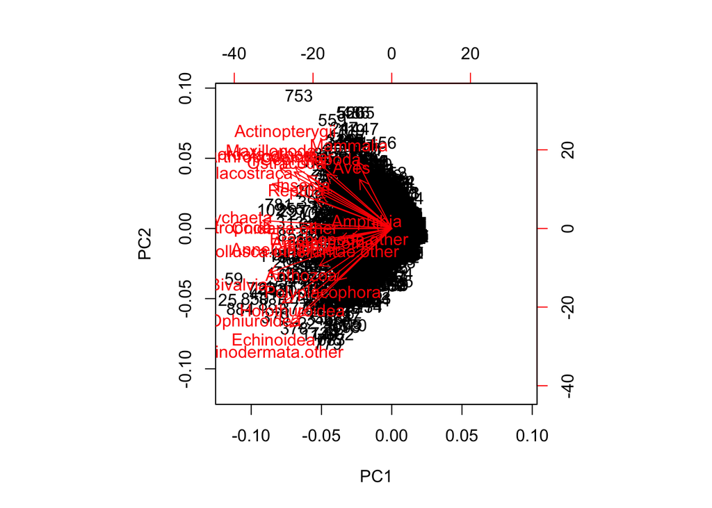

```r
marine.pca <- prcomp(mar.PC, scale = TRUE)
biplot(marine.pca)
```

```r
summary(marine.pca)
```

```
## Importance of components%s:
##                           PC1     PC2     PC3     PC4     PC5     PC6
## Standard deviation     2.4098 1.38974 1.24015 1.20610 1.10803 1.03280
## Proportion of Variance 0.2151 0.07153 0.05696 0.05388 0.04547 0.03951
## Cumulative Proportion  0.2151 0.28661 0.34357 0.39745 0.44292 0.48243
##                            PC7     PC8     PC9    PC10    PC11    PC12
## Standard deviation     1.02022 0.98949 0.97679 0.93970 0.92383 0.89261
## Proportion of Variance 0.03855 0.03626 0.03534 0.03271 0.03161 0.02951
## Cumulative Proportion  0.52098 0.55724 0.59258 0.62528 0.65689 0.68640
##                           PC13    PC14    PC15    PC16    PC17    PC18
## Standard deviation     0.87642 0.86412 0.84775 0.82526 0.80260 0.79108
## Proportion of Variance 0.02845 0.02766 0.02662 0.02522 0.02386 0.02318
## Cumulative Proportion  0.71485 0.74251 0.76912 0.79435 0.81821 0.84138
##                           PC19    PC20    PC21    PC22    PC23   PC24
## Standard deviation     0.76326 0.73203 0.71901 0.70760 0.70215 0.6696
## Proportion of Variance 0.02158 0.01985 0.01915 0.01854 0.01826 0.0166
## Cumulative Proportion  0.86296 0.88281 0.90196 0.92050 0.93876 0.9554
##                           PC25    PC26    PC27
## Standard deviation     0.66070 0.63194 0.60771
## Proportion of Variance 0.01617 0.01479 0.01368
## Cumulative Proportion  0.97153 0.98632 1.00000
```